# P405_Analysis

AY

7/21/2021

# Introduction

Again, not much is known, as the data is just there.

## create pathes

```bash
scripts="/home/yeroslaviz/poolFolders/pool-bcfngs/scripts"
starindex="/home/yeroslaviz/poolFolders/pool-bcfngs/genomes/Mmu.GrCm38/starIndex2.7.7a/"
gtf="/home/yeroslaviz/poolFolders/pool-bcfngs/genomes/Mmu.GrCm38.gtf"

basis="/home/yeroslaviz/poolFolders/pool-bcfngs/fastq_files/P405/P405_20210706_PM_MR"
fastqc="$basis/fastqcResults"
rawdata="$basis/conc.fastq"
results="$basis/results"
bamFiles="$basis/mapping/Mmu.GrCm38/star/"
quant="$basis/quantification"
```

# Quality control using `FastQC`

For the QC of the raw samples we used here the tool `fastQC` (version 011.7, @fastqc). The tool was ran as part of our NGS core facility pipeline and is done automatically By Kim.

The results of the fastqc run can be summarized by the python script `CheckFastqResults.py`. After finishing the run, a summary files is created and the results are being visualized by colors.

```bash
cd $fastqc # change to the folder of the fastqc output files

python $scripts/CheckFastqResults.py # create a csv file of summary for the results
```

A header row the file was added with the different tests run by `fastqc`:

Using `sed -i '1^/...'` the line below is added at the beginning of the file w.o. opening it.

```bash
sed '1s/^/Name,Basic_Statistics,Per_base_sequence_quality,Per_tile_sequence_quality,Per_sequence_quality_scores,Per_base_sequence_content,Per_sequence_GC_content,Per_base_N_content,Sequence_Length_Distribution,Sequence_Duplication_Levels,Overrepresented_sequences,Adapter_Content,Kmer_Content \n/ ' all_mod_scores.csv >$results/all_mod_scores.csv
rm all_mod_scores.csv
cd $results
```

and the csv file was read into R to create a heatmap

this was done by using the script QC.plot.R

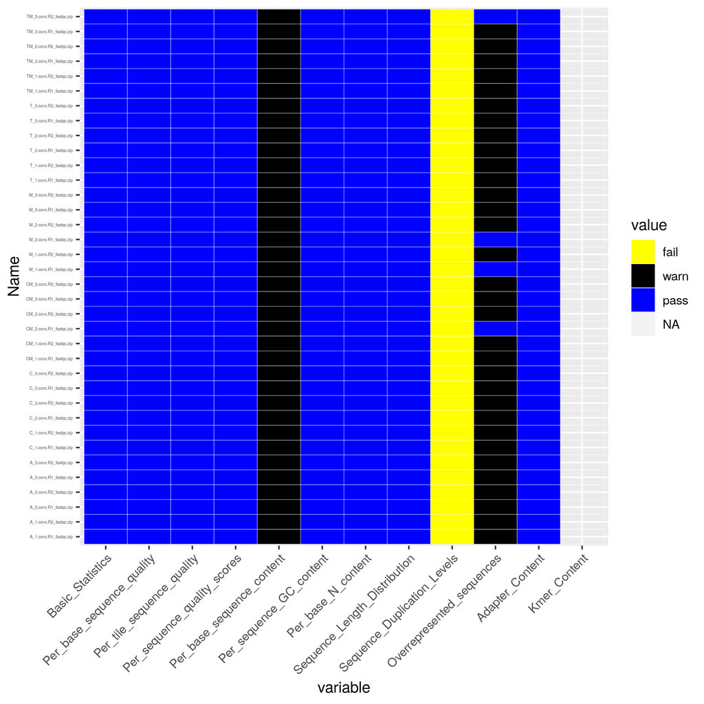

Results of the fastqc Runs.

```bash
Rscript $scripts/QC.plot.R ./ QC.Results_MR_P405.png
```

# Mapping

The Mapping was done using our automated Mapping workflow. STAR version is - 2.7.7a

# Quantification with `featureCounts`

For the quantification, the tool `fateureCounts` (version @featureCounts) from the `subread` package was used.

```bash
featureCounts -T 12 -a $gtf -t exon -g gene_id -M -o quantification/GeneCounts.txt $bamFiles/*.bam >>  quantification/quantification.log 2>&1
```

# Differential Expression Analysis

## Libraries

```r
library("DESeq2")
library("biomaRt")
library("AnnotationHub")
library("RColorBrewer")
library("viridis")
library("ggrepel")
library("EnhancedVolcano")
library("pheatmap")
library("tidyverse")
```

## Read Meta Info

Reading in the data and metadata information

```r
cts <- read.delim2("results/counts/GeneCounts.txt",row.names=1, sep = "\t", skip = 1)
cts <- cts[,-c(1:5)]
colnames(cts) <- gsub(pattern = "X.home.yeroslaviz.poolFolders.pool.bcfngs.fastq_files.P405.P405_20210706_PM_MR.mapping.Mmu.GrCm38.star..(.*).bam",
                      replacement = "\\1", x = colnames(cts) )

coldata <- read.delim2("metaInfo.txt", row.names=1, colClasses = c("factor","factor","factor" ))
```

## Adding gene annotations

### using `AnnotationHub` package

```r
# Connect to AnnotationHub
ah <- AnnotationHub()

# Access the Ensembl database for organism
ahDb <- query(ah,
              pattern = c("Mus musculus", "EnsDb"),
              ignore.case = TRUE)

# Acquire the latest annotation files
id <- ahDb %>%
        mcols() %>%
        rownames() %>%
        tail(n = 1)

# Download the appropriate Ensembldb database
edb <- ah[[id]]

# Extract gene-level information from database
annotationsHub <- genes(edb,
                     return.type = "data.frame")

# Select annotations of interest
annotationsHub <- annotationsHub %>%
        dplyr::select(gene_id, gene_name, seq_name, gene_biotype, description,entrezid)

head(annotationsHub)

saveRDS(annotationsHub, file = "annotationsHub.mmu.RDS" )
```